# Part 2 Homework

Packages used

```r
library(AppliedPredictiveModeling)
library(Amelia)
library(doParallel)
library(missForest)
library(cwhmisc)
library(MASS)
library(forecast)
library(tidyverse)
library(pls)
library(caret)
library(data.table)
library(psych)
library(mlbench)
library(nnet)
library(earth)
library(kernlab)
library(Metrics)
library(party)
```

# Chapter 6

## Problem 6.3

A chemical manufacturing process for a pharmaceutical product was discussed in Sect. 1.4. In this problem, the objective is the understand the relationship between biological measurements of the raw materials (predictors), measurements of the manufacturing process (predictors), and the response of product yield. Biological predictors cannot be changed but can be used to assess the quality of the raw material before processing. On the other hand, manufacturing process predictors can be changed in the manufacturing process. Improving product yield by 1 % will boost revenue by approximately one hundred thousand dollars per batch.

### a. Start $ and use the commands to load the data:

```r
library(AppliedPredictiveModeling)
data("ChemicalManufacturingProcess")
```

The matrix processPredictors contains the 57 predictors (12 describing the input biological material and 45 describing the process predictors) for the 176 manufacturing runs. yield contains the percent yield for each run.

### b. A small percentage of cells in the predictor set contains missing values. Use an imputation function to fill in these missing values.

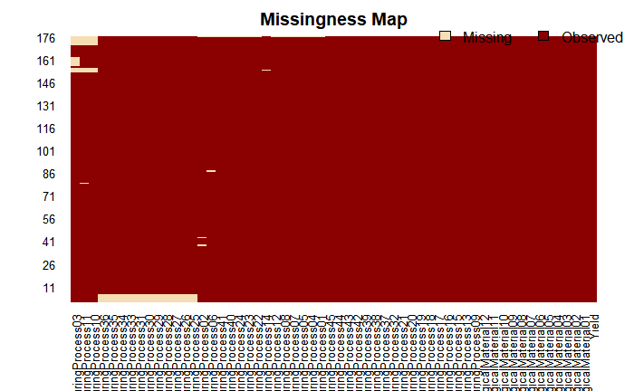

```r
library(Amelia)
missmap(ChemicalManufacturingProcess)
```

```r
library(doParallel)
library(missForest)
set.seed(1234)
registerDoParallel(cores=3)
chem.imput <- missForest(ChemicalManufacturingProcess, ntree = 100, parallelize = "forests")$ximp
```

```
  missForest iteration 1 in progress...done!
  missForest iteration 2 in progress...done!
  missForest iteration 3 in progress...done!
  missForest iteration 4 in progress...done!
```

```r
data.set <- list(org.data.set = chem.imput)
```

### c. Split the data into a training and a test set, pre-process the data, and tune a model of your choice from this chapter. What is the optimal value of the performance metric?

> Lets explore the distribution of the variables

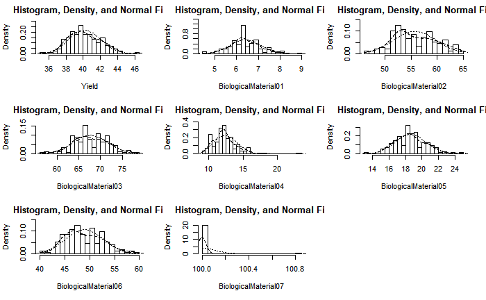

```r
library(psych)
multi.hist(data.set$org.data.set[1:8])
```

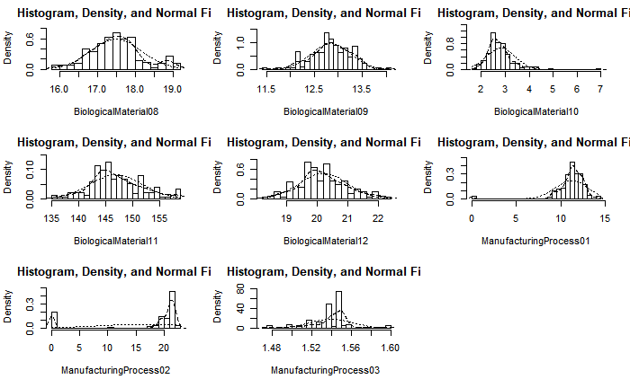

```r
multi.hist(data.set$org.data.set[9:16])
```

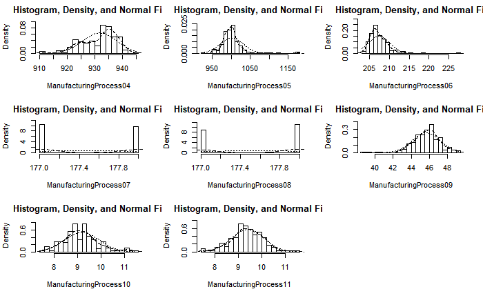

```r
multi.hist(data.set$org.data.set[17:24])
```

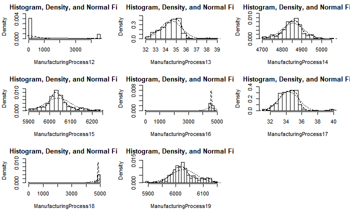

```r
multi.hist(data.set$org.data.set[25:32])
```

The distributions of several of the variables are noticeably skewed, so we will obtain the box cox transformation lambda

```r
variables.to.transform <- c("BiologicalMaterial04", "ManufacturingProcess01",
                            "ManufacturingProcess02","ManufacturingProcess03",
                            "ManufacturingProcess06", "ManufacturingProcess07",
                            "ManufacturingProcess08","ManufacturingProcess12",
                            "ManufacturingProcess16","ManufacturingProcess18")
results <- NULL
for (i in 1:length(variables.to.transform)){
  results[[i]] <- list(variable = variables.to.transform[[i]],
                       lambda = BoxCox.lambda(data.set$org.data.set[,variables.to.transform[[i]]]))}
results
```

```
[[1]]
[[1]]$variable
[1] "BiologicalMaterial04"

[[1]]$lambda
[1] -0.9999242


[[2]]
[[2]]$variable
[1] "ManufacturingProcess01"

[[2]]$lambda
[1] 1.999959


[[3]]
[[3]]$variable
[1] "ManufacturingProcess02"

[[3]]$lambda
[1] 1.999959


[[4]]
[[4]]$variable
[1] "ManufacturingProcess03"

[[4]]$lambda
[1] -0.9999242


[[5]]
[[5]]$variable
[1] "ManufacturingProcess06"

[[5]]$lambda
[1] -0.9999242


```

[output cut: 23 more lines]

```

[[9]]
[[9]]$variable
[1] "ManufacturingProcess16"

[[9]]$lambda
[1] 1.999959


[[10]]
[[10]]$variable
[1] "ManufacturingProcess18"

[[10]]$lambda
[1] 1.999959
```

> We have our lambda transformations and we can apply them to our data set then set our test and train splices.

```r
trans.data.set <- data.set$org.data.set %>%
                    mutate(BiologicalMaterial04.boxcoxtrans =
                             BoxCox(BiologicalMaterial04, -0.99992424816297),
                           ManufacturingProcess01.boxcoxtrans =
                             BoxCox(ManufacturingProcess01, 1.99995900720725),
                           ManufacturingProcess02.boxcoxtrans =
                             BoxCox(ManufacturingProcess02, 1.99995900720725),
                           ManufacturingProcess03.boxcoxtrans =
                             BoxCox(ManufacturingProcess03, -0.99992424816297),
                           ManufacturingProcess06.boxcoxtrans =
                             BoxCox(ManufacturingProcess06, -0.99992424816297),
                           ManufacturingProcess07.boxcoxtrans =
                             BoxCox(ManufacturingProcess07,-0.99992424816297),
                           ManufacturingProcess08.boxcoxtrans =
                             BoxCox(ManufacturingProcess08, 1.99992424816297),
                           ManufacturingProcess12.boxcoxtrans =
                             BoxCox(ManufacturingProcess12, 0.0000410225926326142),
                           ManufacturingProcess16.boxcoxtrans =
                             BoxCox(ManufacturingProcess16, 1.99995900720725),
                           ManufacturingProcess18.boxcoxtrans =
                             BoxCox(ManufacturingProcess18, 1.99995900720725))
```

> Splitting the test and training data set

```r
set.seed(123)
```

```r
data.set <- c(data.set, list(trans.data.set = trans.data.set))  %>%
            c(., list(train.test.split = floor(0.75 * nrow(chem.imput)))) %>%
            c(., train.index = list(sample(seq_len(nrow(chem.imput)), size = .$train.test.split))) %>%
            c(., train = list(as.data.frame(trans.data.set[.$train.index,])), test = list(as.data.frame(trans.data.set[-.$train.index,])))
```

> Now we can proceed with the model of choice which is the Partial Least Squares. Note that the evaluation below relied heavily on this rpubs post- https://rpubs.com/omicsdata/pls.

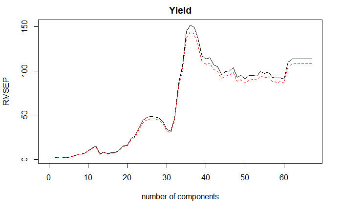

```r
library(pls)
chem.plsFit <- plsr(Yield ~ ., data =  data.set$train, validation = "CV")
validationplot(chem.plsFit, val.type="RMSEP")
```

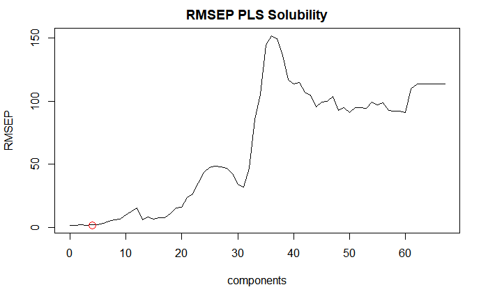

```r
pls.RMSEP <- RMSEP(chem.plsFit, estimate="CV")
plot(pls.RMSEP, main="RMSEP PLS Solubility", xlab="components")
min_comp <- which.min(pls.RMSEP$val)
points(min_comp, min(pls.RMSEP$val), pch=1, col="red", cex=1.5)
```

> Our optimal number of components is 4.

[1] RPubs - Partial Least Square Regression. N.p., n.d. Web. 14 Nov. 2017. - https://rpubs.com/omicsdata/pls

### d. Predict the response for the test set. What is the value of the performance metric and how does this compare with the resampled performance metric on the training set?

> Our results from our training set

```r
chem.plsPredict.train <-  predict(chem.plsFit, data = data.set$train, ncomp = min_comp)
pls.eval <- data.frame(obs = data.set$train[,1], pred = chem.plsPredict.train[,1,1])
defaultSummary(pls.eval)
```

```
     RMSE  Rsquared       MAE
1.7107711 0.1356225 1.3528529
```

> Results from the test set

```r
chem.plsPredict <- predict(chem.plsFit, data = data.set$test, ncomp = min_comp)
pls.eval <- data.frame(obs = data.set$test[,1], pred = chem.plsPredict[,1,1])
defaultSummary(pls.eval)
```

```
       RMSE    Rsquared         MAE
1.919554041 0.004446489 1.591550712
```

> While our RMSE is within range of both the training and test data set the Rsquared is significantly less for the test set suggesting a model that does not explain much of the variation. This may not be the most optimal model.

### e. Which predictors are most important in the model you have trained? Do either the biological or process predictors dominate the list?

```r
library(data.table)
dt <- setDT(varImp(chem.plsFit), keep.rownames = TRUE)[]
options(scipen=99)
dt[order(-Overall)]
```

| rn | Overall |
| --- | --- |
| BiologicalMaterial04.boxcoxtrans | 12.6114775019205 |
| ManufacturingProcess03.boxcoxtrans | 3.2867808675217 |
| ManufacturingProcess36 | 2.5070484769765 |
| ManufacturingProcess40 | 1.2458019906266 |
| ManufacturingProcess41 | 1.0152494916164 |
| ManufacturingProcess03 | 0.9703353111923 |
| ManufacturingProcess29 | 0.4691409134521 |
| ManufacturingProcess45 | 0.3837734610661 |
| ManufacturingProcess34 | 0.3274740845679 |
| ManufacturingProcess30 | 0.2787272718870 |

[output cut: 57 more lines]

> We see that the Manufacturing Processes dominate the list for variable importance with a few biological materials having importance.

### f. Explore the relationships between each of the top predictors and the response. How would this information be helpful in improving yield in future runs of the manufacturing process?

```r
data.set$org.data.set %>% dplyr::select(Yield, ManufacturingProcess40) %>% cor() %>% .[2]
```

```
[1] -0.04647267
```

We see a negative correlation ManufacturingProcess40 and Yield, which suggests that ManufacturingProcess40 represents a process that can decrease the Yield. We cannot say that ManufacturingProcess40 itself decrease Yield, only that a negative relationship exists.

```r
data.set$org.data.set %>% dplyr::select(Yield, BiologicalMaterial12) %>% cor() %>% .[2]
```

```
[1] 0.3674976
```

We actually see the opposite for the Biological indicator in that there is a positive correlation to Yield. We cannot say that BiologicalMaterial12 itself improves Yield, only that a positive relationship exists.

# Chapter 7

## Problem 7.2

Friedman (1991) introduced several benchmark data sets created by simulation. One of these simulations used the following nonlinear equation to create data:

$$y = 10sin(\pi x_1 x_2) + 20(x_3 -0.5)^2+10x_4 +5x_5 + N(0,\sigma^2)$$
where the ex values are random variables uniformly distributed between [0,1] (there are also 50 other non-informative variables also created in simulation). The package mlbench contains a function called mlbench.friedman1 that simulates these data:

```r
set.seed(1234)
trainingData <- mlbench.friedman1(200, sd = 1)
trainingData$x <- data.frame(trainingData$x)
#featurePlot(trainingData$x, trainingData$y)
testData <- mlbench.friedman1(5000, sd = 1)
testData$x <- data.frame(testData$x)
```

### Tune several models on these data.

> Training Neural Net

```r
nnetFit <- nnet(testData$x, testData$y,
                size = 5,
                decay = .01,
                maxit = 500,
                MaxNWts = 5 * (ncol(testData$x) + 1) + 5 + 1)
results <- predict(nnetFit, trainingData$x) %>% cbind(.,trainingData$y) %>% as.data.frame()
colnames(results) <- c("predicted", "actual")
rmse(results$actual, results$predicted)
```

```
[1] 14.36606
```

> Training MARS

```r
marsFit <- earth(testData$x, testData$y)
results <- predict(marsFit, trainingData$x) %>% cbind(.,trainingData$y) %>% as.data.frame()
colnames(results) <- c("predicted", "actual")
rmse(results$actual, results$predicted)
```

```
[1] 1.785523
```

> Train K-Nearest Neighbors

> This method at times will work and other times will not due to a known issue with the latest caret release. The error is “unable to find variable”optimismBoot“”, I am leaving the code in to show my attempt but note that this will not run appropriately.

```r
#At one point I got the error optimismBoot not found, installing caret from github resolved the issue.
knnTune <- train(testData$x, testData$y,
                method = "knn",
                preProc = c("center", "scale"),
                trace = FALSE)
results <- predict(knnTune, trainingData$x) %>% cbind(.,trainingData$y) %>% as.data.frame()
colnames(results) <- c("predicted", "actual")
rmse(results$actual, results$predicted)
```

### Which models appear to give the best performance? Does MARS select informative predictors (those named X1-X5).

> The model with the lowest performance metric that we are using is the RMSE value of 1.7855 for the MARS method.

```r
varImp(marsFit)
```

|  | Overall |
| --- | --- |
| X4 | 100.00000 |
| X1 | 78.68733 |
| X2 | 63.36434 |
| X5 | 44.56206 |
| X3 | 31.99334 |
| X6 | 0.00000 |
| X7 | 0.00000 |
| X8 | 0.00000 |
| X9 | 0.00000 |
| X10 | 0.00000 |

> The MARS method did select variables with the most important of X1-X5 as shown in our previous table.

## Problem 7.5

Exercise 6.3 describes data for a chemical manufacturing process. Use the same data imputation, data splitting, and pre-processing steps as before and train several nonlinear regression models.

> The below is the minimum steps needed to recreate the data set from Chapter 6. Please see problem from Chapter 6 for complete breakdown for each step and reasons behind the choices.

```r
library(AppliedPredictiveModeling)
data("ChemicalManufacturingProcess")
```

```r
library(missForest)
set.seed(1234)
registerDoParallel(cores=3)
chem.imput <- missForest(ChemicalManufacturingProcess, ntree = 100)$ximp
```

```
  missForest iteration 1 in progress...done!
  missForest iteration 2 in progress...done!
  missForest iteration 3 in progress...done!
  missForest iteration 4 in progress...done!
```

```r
data.set <- list(org.data.set = chem.imput)
```

```r
trans.data.set <- data.set$org.data.set %>%
                    mutate(BiologicalMaterial04.boxcoxtrans =
                             BoxCox(BiologicalMaterial04, -0.99992424816297),
                           ManufacturingProcess01.boxcoxtrans =
                             BoxCox(ManufacturingProcess01, 1.99995900720725),
                           ManufacturingProcess02.boxcoxtrans =
                             BoxCox(ManufacturingProcess02, 1.99995900720725),
                           ManufacturingProcess03.boxcoxtrans =
                             BoxCox(ManufacturingProcess03, -0.99992424816297),
                           ManufacturingProcess06.boxcoxtrans =
                             BoxCox(ManufacturingProcess06, -0.99992424816297),
                           ManufacturingProcess07.boxcoxtrans =
                             BoxCox(ManufacturingProcess07,-0.99992424816297),
                           ManufacturingProcess08.boxcoxtrans =
                             BoxCox(ManufacturingProcess08, 1.99992424816297),
                           ManufacturingProcess12.boxcoxtrans =
                             BoxCox(ManufacturingProcess12, 0.0000410225926326142),
                           ManufacturingProcess16.boxcoxtrans =
                             BoxCox(ManufacturingProcess16, 1.99995900720725),
                           ManufacturingProcess18.boxcoxtrans =
                             BoxCox(ManufacturingProcess18, 1.99995900720725))
```

```r
data.set <- c(data.set, list(trans.data.set = trans.data.set))  %>%
            c(., list(train.test.split = floor(0.75 * nrow(chem.imput)))) %>%
            c(., train.index = list(sample(seq_len(nrow(chem.imput)), size = .$train.test.split))) %>%
            c(., train = list(as.data.frame(trans.data.set[.$train.index,])), test = list(as.data.frame(trans.data.set[-.$train.index,])))
```

### Model Selection

> Training Neural Net

```r
nnetFit <- nnet(data.set$train %>% dplyr::select(-Yield), data.set$train$Yield,
                size = 5,
                decay = .01,
                maxit = 500,
                trace = FALSE)
results <- predict(nnetFit,data.set$test %>% dplyr::select(-Yield)) %>% cbind(.,data.set$test$Yield) %>% as.data.frame()
colnames(results) <- c("predicted", "actual")
rmse(results$actual, results$predicted)
```

```
[1] 38.89715
```

> Training MARS

```r
marsFit <- earth(data.set$train %>% dplyr::select(-Yield), data.set$train$Yield)
results <- predict(marsFit, data.set$test %>% dplyr::select(-Yield)) %>% cbind(.,data.set$test$Yield) %>% as.data.frame()
colnames(results) <- c("predicted", "actual")
rmse(results$actual, results$predicted)
```

```
[1] 1.401761
```

> Attempts to model a K-nearest neighbor was unsuccesful, the caret package appears to have a conflict with optimismboot and is unable to accomodate this data set. https://stackoverflow.com/questions/46244763/caret-train-function-unable-to-find-variable-optimismboot

### a. Which nonlinear regression model gives the optimal re-sampling and test set performance?

> The nonlinear regression model with the best test set performance was again the MARS model with an RMSE of 1.401761.

### b. Which predictors are the most important in the optimal nonlinear regression model? Do either the biological or process variables dominate the list? How do the top ten important predictors compare to the top ten predictors from the optimal linear model?

```r
library(data.table)
dt <- setDT(varImp(marsFit), keep.rownames = TRUE)[]
options(scipen=99)
dt[order(-Overall)]
```

| rn | Overall |
| --- | --- |
| ManufacturingProcess32 | 100.00000 |
| ManufacturingProcess09 | 67.72174 |
| ManufacturingProcess13 | 42.33973 |
| ManufacturingProcess33 | 37.43641 |
| BiologicalMaterial02 | 37.25570 |
| BiologicalMaterial03 | 37.25570 |
| ManufacturingProcess28 | 31.32309 |
| ManufacturingProcess43 | 27.29428 |
| ManufacturingProcess04 | 19.81703 |
| BiologicalMaterial05 | 12.51240 |

[output cut: 57 more lines]

> We see that the Manufacturing Processes dominate the list for variable importance with a few biological materials having importance. This is similar to our previous model however we do see a few more biological materials variables. Although we see none of the variables are previous model found important which suggests that the manufacturing processes contain a lot of information on the variance of yield.

### c. Explore the relationships between the top predictors and the response for the predictors that are unique to the optimal nonlinear regression model. Do these plots reveal intuition about the biological or process predictors and their relationship with yield?

```r
subset.data.set <- data.set$trans.data.set %>%
                      dplyr::select(ManufacturingProcess32, ManufacturingProcess09,
                             ManufacturingProcess13,    ManufacturingProcess33,
                             BiologicalMaterial02,  BiologicalMaterial03,
                             ManufacturingProcess28, ManufacturingProcess43,
                             ManufacturingProcess04, BiologicalMaterial05, Yield)
```

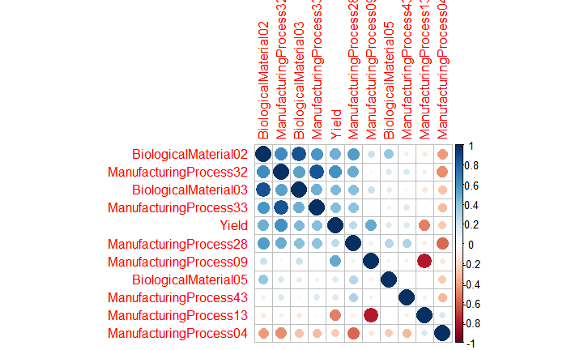

```r
library(corrplot)
correlations <- cor(subset.data.set)
corrplot(correlations, order = "FPC", diag = TRUE)
```

> The correlation plot provides some insight to these important variables. Yield has a mostly positive correlation with many of hte processes but has the strongest negative correlation with only manufacturing processes from our top 10 variables. We also see some very high correlations with other variables in our top variable set which suggests possible issues of multicollinearity.

```r
library(tidyverse)
```

# Chapter 8

## Problem 8.1

### Recreate the simulated data from Exercise 7.2:

```r
library(mlbench)
set.seed(200)
simulated <- mlbench.friedman1(200, sd = 1)
simulated <- cbind(simulated$x, simulated$y)
simulated <- as.data.frame(simulated)
colnames(simulated)[ncol(simulated)] <- "y"
```

### a. Fit a random forest model to all of the predictors, then estimate the variable importance

```r
library(randomForest)
library(caret)
model1 <- randomForest(y ~., data = simulated, importance = TRUE,
                       ntree = 1000)
rfImp <- varImp(model1, scale = FALSE)
rfImp
```

|  | Overall |
| --- | --- |
| V1 | 8.66496174 |
| V2 | 6.36504194 |
| V3 | 0.76724347 |
| V4 | 7.93742254 |
| V5 | 2.10190958 |
| V6 | 0.19154480 |
| V7 | 0.04177869 |
| V8 | -0.08293296 |
| V9 | -0.06267951 |
| V10 | -0.04521494 |

Does the random forest model significantly use the uninformative predictors (V6-V10).

### b. Now add an additional predictor that is highly correlated with one of the informative predictors. For Example:

```r
simulated$duplicate1 <- simulated$V1 + rnorm(200) * .1
cor(simulated$duplicate1, simulated$V1)
```

```
[1] 0.9386619
```

### Fit another random forest model to these data. Did the importance score for V1 change? What happens when you add another predictor that is also highly correlated with V1?

```r
model1 <- randomForest(y ~., data = simulated, importance = TRUE,
                       ntree = 1000)
rfImp <- varImp(model1, scale = FALSE)
```

```r
library(data.table)
dt <- setDT(varImp(model1, scale = FALSE), keep.rownames = TRUE)[]
options(scipen=99)
dt[order(-Overall)]
```

| rn | Overall |
| --- | --- |
| V4 | 6.59026253 |
| V2 | 6.04782043 |
| V1 | 5.34138782 |
| duplicate1 | 4.71267815 |
| V5 | 1.86532068 |
| V3 | 0.54776459 |
| V6 | 0.13680850 |
| V9 | 0.06233358 |
| V10 | 0.05506748 |
| V7 | 0.04745508 |

[output cut: 1 more lines]

> We do see that the importance score has been reduced with the duplicate variable. The interaction between the two variables is reducing the signal we receive from using simple one of the variables.

```r
simulated$duplicate2 <- simulated$V1 + rnorm(200) * .15
cor(simulated$duplicate2, simulated$V1)
```

```
[1] 0.8849327
```

```r
model2 <- randomForest(y ~., data = simulated, importance = TRUE,
                       ntree = 1000)
rfImp <- varImp(model2, scale = FALSE)
```

```r
library(data.table)
dt <- setDT(varImp(model2, scale = FALSE), keep.rownames = TRUE)[]
options(scipen=99)
dt[order(-Overall)]
```

| rn | Overall |
| --- | --- |
| V4 | 7.292570850 |
| V2 | 6.562165756 |
| V1 | 4.562573722 |
| duplicate1 | 4.295437598 |
| V5 | 2.070957251 |
| duplicate2 | 1.384370802 |
| V3 | 0.517422886 |
| V6 | 0.132806443 |
| V7 | 0.072280073 |
| V9 | -0.003797135 |

[output cut: 2 more lines]

> We don’t any improvements are reductions in the variable importance but it is reducing variable importance of other variables that may be meaningful for other reasons like literature based reasons.

### c. Use the cforest function in the party package to fit a random forest model using conditional inference trees. The party package function varimp can calculate predictor importance. The conditional argument of that function toggles between the traditional importance measure and the modified version described in Strobl et Al. (2007). Do these importance show the same pattern as the traditional random forest model?

```r
library(party)
fit.cforest <- cforest(y ~., data = simulated)
```

```r
library(data.table)
dt <- setDT(party::varimp(fit.cforest, conditional = TRUE) %>% data.frame(), keep.rownames = TRUE)[]
options(scipen=99)
dt[order(-.)]
```

| rn | . |
| --- | --- |
| V4 | 5.281196888 |
| V2 | 4.373678395 |
| duplicate1 | 1.719885895 |
| V1 | 1.288320322 |
| V5 | 0.971063628 |
| duplicate2 | 0.276946982 |
| V3 | 0.021087453 |
| V6 | 0.019535747 |
| V7 | 0.011797289 |
| V10 | 0.002561214 |

[output cut: 2 more lines]

```r
dt <- setDT(party::varimp(fit.cforest, conditional = FALSE) %>% data.frame(), keep.rownames = TRUE)[]
options(scipen=99)
dt[order(-.)]
```

| rn | . |
| --- | --- |
| V4 | 6.57619578 |
| V2 | 5.79417540 |
| duplicate1 | 4.99198355 |
| V1 | 3.74038496 |
| V5 | 1.62301336 |
| duplicate2 | 1.02429697 |
| V7 | 0.04711682 |
| V9 | 0.02985211 |
| V6 | 0.01570609 |
| V3 | 0.01140049 |

[output cut: 2 more lines]

> The top few variables remain at the same level of importance for both models. However, the variable importance is less using conditional inference trees via cpart from the party package.

### d. Repeat this process with different tree models, such as boosted trees and Cubist. Does the same pattern occur?

```r
library(Cubist)
fit.cubist <- cubist(simulated %>% select(-y), simulated$y, committees = 4)
fit.cubist
```

```
Call:
cubist.default(x = simulated %>% select(-y), y = simulated$y, committees = 4)

Number of samples: 200
Number of predictors: 12

Number of committees: 4
Number of rules per committee: 1, 4, 2, 5
```

```r
dt <- setDT(varImp(fit.cubist) %>% data.frame(), keep.rownames = TRUE)[]
options(scipen=99)
dt[order(-Overall)]
```

| rn | Overall |
| --- | --- |
| V2 | 64.0 |
| V1 | 63.5 |
| V4 | 50.0 |
| V5 | 49.0 |
| V3 | 35.0 |
| duplicate1 | 25.5 |
| duplicate2 | 7.5 |
| V6 | 4.0 |
| V7 | 0.0 |
| V8 | 0.0 |

[output cut: 2 more lines]

> Using the cubist model we actually get very different results. In fact, the model appears to adjust for the highly correlated variables and gives us variable importance that more closely match our original data set before the added variables.

## Problem 8.2

### Use a simulation to show tree bias with different granularity.

```r
library(mlbench)
library(tidyverse)
library(rpart)
library(rpart.plot)
library(caret)
data.set <- twoClassSim(300, noiseVars = 8, corrVar = 6, corrValue = 0.8) %>%
            mutate(TwoFactor1 = as.factor(round(TwoFactor1, 0)),
                   TwoFactor2 = as.factor(round(TwoFactor2, 0)))
```

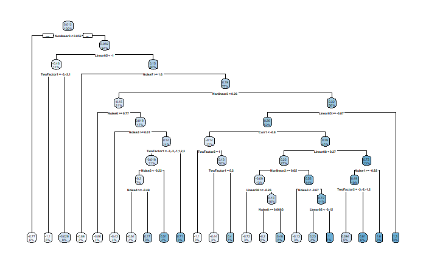

```r
r.fit <- rpart(Linear01 ~ ., data=data.set)
rpart.plot(r.fit)
```

```r
library(data.table)
dt <- setDT(varImp(r.fit), keep.rownames = TRUE)[]
options(scipen=99)
dt[order(-Overall)]
```

| rn | Overall |
| --- | --- |
| TwoFactor2 | 1.62598157 |
| TwoFactor1 | 0.92692954 |
| Noise1 | 0.76886577 |
| Linear09 | 0.72470303 |
| Linear08 | 0.71648162 |
| Noise5 | 0.69175952 |
| Noise6 | 0.61321134 |
| Noise3 | 0.59730960 |
| Linear02 | 0.59195971 |
| Noise4 | 0.54439475 |

[output cut: 19 more lines]

## Problem 8.3

In stochastic gradient boosting the bagging fraction and learning rate will govern the construction of the trees as they are guided by gradient. Although the optimal values of these parameters should be obtained through the tuning process, it is helpful to understand how the magnitudes of these parameters affect magnitudes of variable importance. Figure 8.24 provides the variable importance plots for boosting using two extreme values for the bagging fraction (0.1 and 0.9) and the learning rate (0.1 and 0.9) for the solubility data. The left-had plot has both parameters set to 0.1, and the right-hand plot has both set to 0.9:

### a. Why does the model on the right focus its importance on just the first few of predictors, whereas the model on the left spreads importance across more predictors?

> A learning rate closer to 1 will make less corrections for each tree added to the model. A high bagging fraction closer to 1 indicates more of the data is used which can lead to overfitting. So as the learning rate and bagging fraction increase, the importance will be placed on fewer and fewer predictors.

### b. Which model do you think would be more predictive of other samples?

> Subsequently, if the parameters increase the model performance will then decrease. Therefore, the model on the left will perform better. Although, I would be cautious about usefulness. If a model uses variables that can’t always be reliably captured than a model dependent on very few variables may be more powerful.

### c. How would increasing interaction depth affect the slope of predictor importance for either model in Fig. 8.24?

> Interaction depth specifies the tree depth and node splits. As the tree depth increase, and more node splits occur the variable importance becomes spread across more predictors. In both models the variable importance would decrease for the top variables and increase for less important variables. If we have any highly correlated variables we may actually see a swap of importance between the two variables.

## Problem 8.7

Refer to Exercise 6.3 and 7.5 which describe a chemical manufacturing process. Use the same data imputation, data splitting, and pre-processing steps as before and train several tree-based models:

```r
library(missForest)
library(AppliedPredictiveModeling)
library(doParallel)
data("ChemicalManufacturingProcess")
set.seed(1234)
registerDoParallel(cores=3)
chem.imput <- missForest(ChemicalManufacturingProcess, ntree = 100)$ximp
```

```
  missForest iteration 1 in progress...done!
  missForest iteration 2 in progress...done!
  missForest iteration 3 in progress...done!
  missForest iteration 4 in progress...done!
```

```r
data.set <- list(org.data.set = chem.imput)
```

```r
library(tidyverse)
library(caret)
library(forecast)
library(MASS)
trans.data.set <- data.set$org.data.set %>%
                    mutate(BiologicalMaterial04.boxcoxtrans =
                             BoxCox(BiologicalMaterial04, -0.99992424816297),
                           ManufacturingProcess01.boxcoxtrans =
                             BoxCox(ManufacturingProcess01, 1.99995900720725),
                           ManufacturingProcess02.boxcoxtrans =
                             BoxCox(ManufacturingProcess02, 1.99995900720725),
                           ManufacturingProcess03.boxcoxtrans =
                             BoxCox(ManufacturingProcess03, -0.99992424816297),
                           ManufacturingProcess06.boxcoxtrans =
                             BoxCox(ManufacturingProcess06, -0.99992424816297),
                           ManufacturingProcess07.boxcoxtrans =
                             BoxCox(ManufacturingProcess07,-0.99992424816297),
                           ManufacturingProcess08.boxcoxtrans =
                             BoxCox(ManufacturingProcess08, 1.99992424816297),
                           ManufacturingProcess12.boxcoxtrans =
                             BoxCox(ManufacturingProcess12, 0.0000410225926326142),
                           ManufacturingProcess16.boxcoxtrans =
                             BoxCox(ManufacturingProcess16, 1.99995900720725),
                           ManufacturingProcess18.boxcoxtrans =
                             BoxCox(ManufacturingProcess18, 1.99995900720725))
```

```r
data.set <- c(data.set, list(trans.data.set = trans.data.set))  %>%
            c(., list(train.test.split = floor(0.75 * nrow(chem.imput)))) %>%
            c(., train.index = list(sample(seq_len(nrow(chem.imput)), size = .$train.test.split))) %>%
            c(., train = list(as.data.frame(trans.data.set[.$train.index,])), test = list(as.data.frame(trans.data.set[-.$train.index,])))
```

### a. Which tree-based regression model gives the optimal re-sampling and test set performance?

```r
ctrl <- trainControl(method = "boot", number = 15)
rpart.fit  <- train(data.set$train %>% dplyr::select(-Yield), data.set$train$Yield,
                    method = "rpart",
                    metric = "Rsquared",
                    trControl = ctrl)
```

```
There were missing values in resampled performance measures.
```

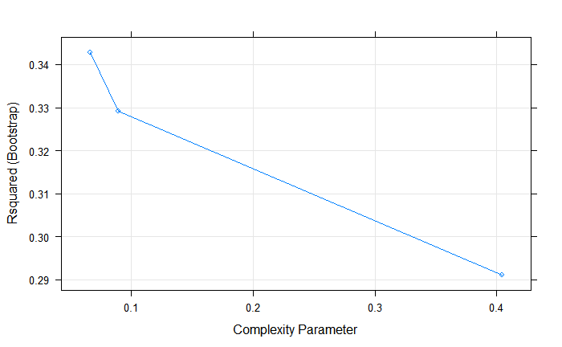

```r
plot(rpart.fit)
```

### c. Plot the optimal single tree with the distribution yields in the terminal nodes. Does this view of the data provide additional knowledge about the biological or process predictors and their relationship with yield?

# Recommender Systems

Imagine 10000 receipts sitting on your table. Each receipt represents a transaction with items that were purchased. The receipt is a representation of stuff that went into a customer’s basket - and therefore ‘Market Basket Analysis’.

That is exactly what the Groceries Data Set contains: a collection of receipts with each line representing 1 receipt and the items purchased. Each line is called a transaction and each column in a row represents an item.

Here is the dataset = GroceryDataSet.csv (comma separated file)

You assignment is to use R to mine the data for association rules. You should report support, confidence and lift and your top 10 rules by lift.

### Loading the Data

# Appendix with all code

All code used previous in below section

```r
library(knitr)
opts_chunk$set(cache = TRUE, message=FALSE, warning=FALSE)
library(AppliedPredictiveModeling)
library(Amelia)
library(doParallel)
library(missForest)
library(cwhmisc)
library(MASS)
library(forecast)
library(tidyverse)
library(pls)
library(caret)
library(data.table)
library(psych)
library(mlbench)
library(nnet)
library(earth)
library(kernlab)
library(Metrics)
library(party)
library(AppliedPredictiveModeling)
library(Amelia)
library(doParallel)
library(missForest)
library(cwhmisc)
library(MASS)
library(forecast)
library(tidyverse)
library(pls)
library(caret)
library(data.table)
library(psych)
library(mlbench)
library(nnet)
library(earth)
library(kernlab)
library(Metrics)
library(party)
library(AppliedPredictiveModeling)
data("ChemicalManufacturingProcess")
library(Amelia)
missmap(ChemicalManufacturingProcess)
library(doParallel)
library(missForest)

set.seed(1234)

registerDoParallel(cores=3)
chem.imput <- missForest(ChemicalManufacturingProcess, ntree = 100, parallelize = "forests")$ximp
data.set <- list(org.data.set = chem.imput)
library(psych)

multi.hist(data.set$org.data.set[1:8])

multi.hist(data.set$org.data.set[9:16])

multi.hist(data.set$org.data.set[17:24])

multi.hist(data.set$org.data.set[25:32])
variables.to.transform <- c("BiologicalMaterial04", "ManufacturingProcess01",
                            "ManufacturingProcess02","ManufacturingProcess03",
                            "ManufacturingProcess06", "ManufacturingProcess07",
                            "ManufacturingProcess08","ManufacturingProcess12",
                            "ManufacturingProcess16","ManufacturingProcess18")

results <- NULL
for (i in 1:length(variables.to.transform)){
  results[[i]] <- list(variable = variables.to.transform[[i]],
                       lambda = BoxCox.lambda(data.set$org.data.set[,variables.to.transform[[i]]]))}
results
trans.data.set <- data.set$org.data.set %>%
                    mutate(BiologicalMaterial04.boxcoxtrans =
                             BoxCox(BiologicalMaterial04, -0.99992424816297),
                           ManufacturingProcess01.boxcoxtrans =
                             BoxCox(ManufacturingProcess01, 1.99995900720725),
                           ManufacturingProcess02.boxcoxtrans =
                             BoxCox(ManufacturingProcess02, 1.99995900720725),
                           ManufacturingProcess03.boxcoxtrans =
                             BoxCox(ManufacturingProcess03, -0.99992424816297),
                           ManufacturingProcess06.boxcoxtrans =
                             BoxCox(ManufacturingProcess06, -0.99992424816297),
                           ManufacturingProcess07.boxcoxtrans =
                             BoxCox(ManufacturingProcess07,-0.99992424816297),
                           ManufacturingProcess08.boxcoxtrans =
                             BoxCox(ManufacturingProcess08, 1.99992424816297),
                           ManufacturingProcess12.boxcoxtrans =
                             BoxCox(ManufacturingProcess12, 0.0000410225926326142),
                           ManufacturingProcess16.boxcoxtrans =
                             BoxCox(ManufacturingProcess16, 1.99995900720725),
                           ManufacturingProcess18.boxcoxtrans =
                             BoxCox(ManufacturingProcess18, 1.99995900720725))
set.seed(123)
data.set <- c(data.set, list(trans.data.set = trans.data.set))  %>%
            c(., list(train.test.split = floor(0.75 * nrow(chem.imput)))) %>%
            c(., train.index = list(sample(seq_len(nrow(chem.imput)), size = .$train.test.split))) %>%
            c(., train = list(as.data.frame(trans.data.set[.$train.index,])), test = list(as.data.frame(trans.data.set[-.$train.index,])))
library(pls)
chem.plsFit <- plsr(Yield ~ ., data =  data.set$train, validation = "CV")
validationplot(chem.plsFit, val.type="RMSEP")
pls.RMSEP <- RMSEP(chem.plsFit, estimate="CV")
plot(pls.RMSEP, main="RMSEP PLS Solubility", xlab="components")
min_comp <- which.min(pls.RMSEP$val)
points(min_comp, min(pls.RMSEP$val), pch=1, col="red", cex=1.5)
chem.plsPredict.train <-  predict(chem.plsFit, data = data.set$train, ncomp = min_comp)
pls.eval <- data.frame(obs = data.set$train[,1], pred = chem.plsPredict.train[,1,1])
defaultSummary(pls.eval)
chem.plsPredict <- predict(chem.plsFit, data = data.set$test, ncomp = min_comp)
pls.eval <- data.frame(obs = data.set$test[,1], pred = chem.plsPredict[,1,1])
defaultSummary(pls.eval)
library(data.table)
dt <- setDT(varImp(chem.plsFit), keep.rownames = TRUE)[]
options(scipen=99)
dt[order(-Overall)]
data.set$org.data.set %>% dplyr::select(Yield, ManufacturingProcess40) %>% cor() %>% .[2]
data.set$org.data.set %>% dplyr::select(Yield, BiologicalMaterial12) %>% cor() %>% .[2]
set.seed(1234)
trainingData <- mlbench.friedman1(200, sd = 1)
trainingData$x <- data.frame(trainingData$x)
#featurePlot(trainingData$x, trainingData$y)
testData <- mlbench.friedman1(5000, sd = 1)
testData$x <- data.frame(testData$x)
nnetFit <- nnet(testData$x, testData$y,
                size = 5,
                decay = .01,
                maxit = 500,
                MaxNWts = 5 * (ncol(testData$x) + 1) + 5 + 1)

results <- predict(nnetFit, trainingData$x) %>% cbind(.,trainingData$y) %>% as.data.frame()
colnames(results) <- c("predicted", "actual")
rmse(results$actual, results$predicted)
marsFit <- earth(testData$x, testData$y)
results <- predict(marsFit, trainingData$x) %>% cbind(.,trainingData$y) %>% as.data.frame()
colnames(results) <- c("predicted", "actual")
rmse(results$actual, results$predicted)
#At one point I got the error optimismBoot not found, installing caret from github resolved the issue.
knnTune <- train(testData$x, testData$y,
                method = "knn",
                preProc = c("center", "scale"),
                trace = FALSE)
results <- predict(knnTune, trainingData$x) %>% cbind(.,trainingData$y) %>% as.data.frame()
colnames(results) <- c("predicted", "actual")
rmse(results$actual, results$predicted)
varImp(marsFit)
library(AppliedPredictiveModeling)
data("ChemicalManufacturingProcess")
library(missForest)
```

```r
set.seed(1234)

registerDoParallel(cores=3)
chem.imput <- missForest(ChemicalManufacturingProcess, ntree = 100)$ximp
data.set <- list(org.data.set = chem.imput)
trans.data.set <- data.set$org.data.set %>%
                    mutate(BiologicalMaterial04.boxcoxtrans =
                             BoxCox(BiologicalMaterial04, -0.99992424816297),
                           ManufacturingProcess01.boxcoxtrans =
                             BoxCox(ManufacturingProcess01, 1.99995900720725),
                           ManufacturingProcess02.boxcoxtrans =
                             BoxCox(ManufacturingProcess02, 1.99995900720725),
                           ManufacturingProcess03.boxcoxtrans =
                             BoxCox(ManufacturingProcess03, -0.99992424816297),
                           ManufacturingProcess06.boxcoxtrans =
                             BoxCox(ManufacturingProcess06, -0.99992424816297),
                           ManufacturingProcess07.boxcoxtrans =
                             BoxCox(ManufacturingProcess07,-0.99992424816297),
                           ManufacturingProcess08.boxcoxtrans =
                             BoxCox(ManufacturingProcess08, 1.99992424816297),
                           ManufacturingProcess12.boxcoxtrans =
                             BoxCox(ManufacturingProcess12, 0.0000410225926326142),
                           ManufacturingProcess16.boxcoxtrans =
                             BoxCox(ManufacturingProcess16, 1.99995900720725),
                           ManufacturingProcess18.boxcoxtrans =
                             BoxCox(ManufacturingProcess18, 1.99995900720725))
data.set <- c(data.set, list(trans.data.set = trans.data.set))  %>%
            c(., list(train.test.split = floor(0.75 * nrow(chem.imput)))) %>%
            c(., train.index = list(sample(seq_len(nrow(chem.imput)), size = .$train.test.split))) %>%
            c(., train = list(as.data.frame(trans.data.set[.$train.index,])), test = list(as.data.frame(trans.data.set[-.$train.index,])))
nnetFit <- nnet(data.set$train %>% dplyr::select(-Yield), data.set$train$Yield,
                size = 5,
                decay = .01,
                maxit = 500,
                trace = FALSE)

results <- predict(nnetFit,data.set$test %>% dplyr::select(-Yield)) %>% cbind(.,data.set$test$Yield) %>% as.data.frame()
colnames(results) <- c("predicted", "actual")
rmse(results$actual, results$predicted)
marsFit <- earth(data.set$train %>% dplyr::select(-Yield), data.set$train$Yield)
results <- predict(marsFit, data.set$test %>% dplyr::select(-Yield)) %>% cbind(.,data.set$test$Yield) %>% as.data.frame()
colnames(results) <- c("predicted", "actual")
rmse(results$actual, results$predicted)
library(data.table)
dt <- setDT(varImp(marsFit), keep.rownames = TRUE)[]
options(scipen=99)
dt[order(-Overall)]
subset.data.set <- data.set$trans.data.set %>%
                      dplyr::select(ManufacturingProcess32, ManufacturingProcess09,
                             ManufacturingProcess13,    ManufacturingProcess33,
                             BiologicalMaterial02,  BiologicalMaterial03,
                             ManufacturingProcess28, ManufacturingProcess43,
                             ManufacturingProcess04, BiologicalMaterial05, Yield)
library(corrplot)
correlations <- cor(subset.data.set)
corrplot(correlations, order = "FPC", diag = TRUE)
library(tidyverse)
library(mlbench)
set.seed(200)
simulated <- mlbench.friedman1(200, sd = 1)
simulated <- cbind(simulated$x, simulated$y)
simulated <- as.data.frame(simulated)
colnames(simulated)[ncol(simulated)] <- "y"
library(randomForest)
library(caret)
model1 <- randomForest(y ~., data = simulated, importance = TRUE,
                       ntree = 1000)
rfImp <- varImp(model1, scale = FALSE)
rfImp
simulated$duplicate1 <- simulated$V1 + rnorm(200) * .1
cor(simulated$duplicate1, simulated$V1)
model1 <- randomForest(y ~., data = simulated, importance = TRUE,
                       ntree = 1000)
rfImp <- varImp(model1, scale = FALSE)
library(data.table)
dt <- setDT(varImp(model1, scale = FALSE), keep.rownames = TRUE)[]
options(scipen=99)
dt[order(-Overall)]
simulated$duplicate2 <- simulated$V1 + rnorm(200) * .15
cor(simulated$duplicate2, simulated$V1)
model2 <- randomForest(y ~., data = simulated, importance = TRUE,
                       ntree = 1000)
rfImp <- varImp(model2, scale = FALSE)
library(data.table)
dt <- setDT(varImp(model2, scale = FALSE), keep.rownames = TRUE)[]
options(scipen=99)
dt[order(-Overall)]
library(party)
fit.cforest <- cforest(y ~., data = simulated)
library(data.table)
dt <- setDT(party::varimp(fit.cforest, conditional = TRUE) %>% data.frame(), keep.rownames = TRUE)[]
options(scipen=99)
dt[order(-.)]
dt <- setDT(party::varimp(fit.cforest, conditional = FALSE) %>% data.frame(), keep.rownames = TRUE)[]
options(scipen=99)
dt[order(-.)]
library(Cubist)
fit.cubist <- cubist(simulated %>% select(-y), simulated$y, committees = 4)
fit.cubist
dt <- setDT(varImp(fit.cubist) %>% data.frame(), keep.rownames = TRUE)[]
options(scipen=99)
dt[order(-Overall)]
library(mlbench)
library(tidyverse)
library(rpart)
library(rpart.plot)
library(caret)

data.set <- twoClassSim(300, noiseVars = 8, corrVar = 6, corrValue = 0.8) %>%
            mutate(TwoFactor1 = as.factor(round(TwoFactor1, 0)),
                   TwoFactor2 = as.factor(round(TwoFactor2, 0)))
r.fit <- rpart(Linear01 ~ ., data=data.set)
rpart.plot(r.fit)
library(data.table)
dt <- setDT(varImp(r.fit), keep.rownames = TRUE)[]
options(scipen=99)
dt[order(-Overall)]
library(missForest)
library(AppliedPredictiveModeling)
library(doParallel)
data("ChemicalManufacturingProcess")

set.seed(1234)

registerDoParallel(cores=3)
chem.imput <- missForest(ChemicalManufacturingProcess, ntree = 100)$ximp
data.set <- list(org.data.set = chem.imput)
library(tidyverse)
library(caret)
library(forecast)
library(MASS)

trans.data.set <- data.set$org.data.set %>%
                    mutate(BiologicalMaterial04.boxcoxtrans =
                             BoxCox(BiologicalMaterial04, -0.99992424816297),
                           ManufacturingProcess01.boxcoxtrans =
                             BoxCox(ManufacturingProcess01, 1.99995900720725),
                           ManufacturingProcess02.boxcoxtrans =
                             BoxCox(ManufacturingProcess02, 1.99995900720725),
                           ManufacturingProcess03.boxcoxtrans =
                             BoxCox(ManufacturingProcess03, -0.99992424816297),
                           ManufacturingProcess06.boxcoxtrans =
                             BoxCox(ManufacturingProcess06, -0.99992424816297),
                           ManufacturingProcess07.boxcoxtrans =
                             BoxCox(ManufacturingProcess07,-0.99992424816297),
                           ManufacturingProcess08.boxcoxtrans =
                             BoxCox(ManufacturingProcess08, 1.99992424816297),
                           ManufacturingProcess12.boxcoxtrans =
                             BoxCox(ManufacturingProcess12, 0.0000410225926326142),
                           ManufacturingProcess16.boxcoxtrans =
                             BoxCox(ManufacturingProcess16, 1.99995900720725),
                           ManufacturingProcess18.boxcoxtrans =
                             BoxCox(ManufacturingProcess18, 1.99995900720725))
data.set <- c(data.set, list(trans.data.set = trans.data.set))  %>%
            c(., list(train.test.split = floor(0.75 * nrow(chem.imput)))) %>%
            c(., train.index = list(sample(seq_len(nrow(chem.imput)), size = .$train.test.split))) %>%
            c(., train = list(as.data.frame(trans.data.set[.$train.index,])), test = list(as.data.frame(trans.data.set[-.$train.index,])))
ctrl <- trainControl(method = "boot", number = 15)
```

```r
rpart.fit  <- train(data.set$train %>% dplyr::select(-Yield), data.set$train$Yield,
                    method = "rpart",
                    metric = "Rsquared",
                    trControl = ctrl)
plot(rpart.fit)
rf.fit   <- train(data.set$train %>% dplyr::select(-Yield), data.set$train$Yield,
                  method = "rf",
                  metric = "Rsquared",
                  trControl = ctrl,
                  importance = TRUE)
plot(rf.fit)
gbm.fit   <- train(data.set$train %>%
                     dplyr::select(-Yield), data.set$train$Yield,
                  method = "gbm",
                  metric = "Rsquared",
                  trControl = ctrl)

plot(gbm.fit)
rf.fit$finalModel
varImp(rf.fit, scale = FALSE)
#https://shiring.github.io/machine_learning/2017/03/16/rf_plot_ggraph

library(dplyr)
library(ggraph)
library(igraph)

tree_func <- function(final_model,
                      tree_num) {

  # get tree by index
  tree <- randomForest::getTree(final_model,
                                k = tree_num,
                                labelVar = TRUE) %>%
    tibble::rownames_to_column() %>%
    # make leaf split points to NA, so the 0s won't get plotted
    mutate(`split point` = ifelse(is.na(prediction), `split point`, NA))

  # prepare data frame for graph
  graph_frame <- data.frame(from = rep(tree$rowname, 2),
                            to = c(tree$`left daughter`, tree$`right daughter`))

  # convert to graph and delete the last node that we don't want to plot
  graph <- graph_from_data_frame(graph_frame) %>%
    delete_vertices("0")

  # set node labels
  V(graph)$node_label <- gsub("_", " ", as.character(tree$`split var`))
  V(graph)$leaf_label <- as.character(round(tree$prediction,2))
  V(graph)$split <- as.character(round(tree$`split point`, digits = 2))

  # plot
  plot <- ggraph(graph, 'dendrogram') +
    theme_bw() +
    geom_edge_link() +
    geom_node_point() +
    geom_node_text(aes(label = node_label), na.rm = TRUE, repel = TRUE) +
    geom_node_label(aes(label = split), vjust = 2.5, na.rm = TRUE, fill = "white") +
    geom_node_label(aes(label = leaf_label, fill = leaf_label), na.rm = TRUE,
                    repel = TRUE, colour = "white", fontface = "bold", show.legend = FALSE) +
    theme(panel.grid.minor = element_blank(),
          panel.grid.major = element_blank(),
          panel.background = element_blank(),
          plot.background = element_rect(fill = "white"),
          panel.border = element_blank(),
          axis.line = element_blank(),
          axis.text.x = element_blank(),
          axis.text.y = element_blank(),
          axis.ticks = element_blank(),
          axis.title.x = element_blank(),
          axis.title.y = element_blank(),
          plot.title = element_text(size = 18))

  print(plot)
}

tree_num <- max(which(rf.fit$finalModel$forest$ndbigtree == min(rf.fit$finalModel$forest$ndbigtree)))
tree_func(final_model = rf.fit$finalModel, tree_num = tree_num)
library(arules)
df <- read.transactions("https://raw.githubusercontent.com/ChristopheHunt/MSDA---Coursework/master/Data%20624/Homework%2011/GroceryDataSet.csv", sep = ",", format = c("basket"))
inspect(df[1:5])
summary(df)
itemFrequencyPlot(df, topN = 10)
rules <- apriori(df, parameter = list(support = 0.01016777, confidence = 0.5))
inspect(sort(rules, by = "lift")[1:10])
```